# tidyverse Demo Using Biological Data

Yixf (Yi Xianfu)

March 25, 2017

# 1 Step0 - Before analysis

## 1.1 Think twice before acting

- What you have?
  - What is the meaning of data?
  - What is the meaning for rows?
  - What is the meaning for each column?
- What you want?
  - Which rows do you want to keep?
  - Which columns do you want to keep?
  - What do you want to add based on the data?

## 1.2 Translate biological data into computer information

- Understand data
  - Row: observation or case or record
  - Column: variable
- Understand analysis
  - Keep rows: filter observations
  - Keep columns: select variables
  - Format data
    - Sort by column(s): arrange
    - Add new column(s): mutate
    - Summary, rename, intersect, join, …

## 1.3 Computer tools

- R (Opts: Python, Perl, shell, …)
- Rstudio
- tidyverse
  - readr
  - tidyr
  - dplyr
  - stringr
  - ggplot2

# 2 Step1 - Analysis

## 2.1 Load packages

If tidyverse has been installed, it can been loaded:

```r
#library(tidyverse)
library(readr)
library(tidyr)
library(dplyr)
library(ggplot2)
library(stringr)
dir.create("output_r", showWarnings=FALSE)
```

## 2.2 Pgen

### 2.2.1 Read in data and understand it

```r
library(readxl)
pgen <- read_excel("pgen.xlsx")
#pgen <- read_tsv("pgen.tsv")
glimpse(pgen)
```

```
## Observations: 3,534
## Variables: 14
## $ SNP                  <chr> "rs2910686", "CNVR8114.2", "rs2272347", "...
## $ probe                <chr> "ILMN_1743145", "ILMN_1730054", "ILMN_231...
## $ gene                 <chr> "ENSG00000164308", "ENSG00000184674", "EN...
## $ chrSNP               <dbl> 5, 22, 7, 10, 12, 12, 10, 12, 17, 14, 18,...
## $ chrgene              <dbl> 5, 22, 7, 10, 12, 12, 10, 12, 17, 14, 18,...
## $ posSNP(hg18)         <dbl> 96278344, 22682685, 128406650, 105012923,...
## $ posTSS(hg18)         <dbl> 96237960, 22706142, 128365230, 105138788,...
## $ distanceTSS          <dbl> 40384, 23457, 41420, 125865, 5828, 26226,...
## $ rho                  <dbl> 0.896, 0.896, -0.894, 0.881, -0.871, 0.87...
## $ pvalue               <dbl> 0, 0, 0, 0, 0, 0, 0, 0, 0, 0, 0, 0, 0, 0,...
## $ log10                <chr> "Inf", "306.3689", "303.10390000000001", ...
## $ pvalue_MUTHER_twin_1 <chr> "0", "NA", "NA", "0", "0", "0", "0", "0",...
## $ pvalue_MUTHER_twin_2 <chr> "0", "NA", "NA", "0", "0", "0", "0", "0",...
## $ pvalue_GEUVADIS      <chr> "0", "NA", "5.8700000000000002E-13", "9.4...
```

```r
summary(pgen)
```

```
##      SNP               probe               gene               chrSNP
##  Length:3534        Length:3534        Length:3534        Min.   : 1.00
##  Class :character   Class :character   Class :character   1st Qu.: 4.00
##  Mode  :character   Mode  :character   Mode  :character   Median :10.00
##                                                           Mean   :10.03
##                                                           3rd Qu.:16.00
##                                                           Max.   :22.00
##     chrgene       posSNP(hg18)        posTSS(hg18)        distanceTSS
##  Min.   : 1.00   Min.   :    92219   Min.   :    43010   Min.   :     6
##  1st Qu.: 4.00   1st Qu.: 30697841   1st Qu.: 30649143   1st Qu.: 10911
##  Median :10.00   Median : 56809250   Median : 56742904   Median : 33072
##  Mean   :10.03   Mean   : 72546838   Mean   : 72520180   Mean   : 86379
##  3rd Qu.:16.00   3rd Qu.:108964540   3rd Qu.:109062132   3rd Qu.: 86162
##  Max.   :22.00   Max.   :246927263   Max.   :246822754   Max.   :999212
##       rho                pvalue             log10
##  Min.   :-0.894000   Min.   :0.000e+00   Length:3534
##  1st Qu.:-0.214000   1st Qu.:0.000e+00   Class :character
##  Median : 0.135000   Median :1.200e-10   Mode  :character
##  Mean   : 0.001191   Mean   :2.619e-06
##  3rd Qu.: 0.217000   3rd Qu.:7.184e-07
##  Max.   : 0.896000   Max.   :1.835e-04
##  pvalue_MUTHER_twin_1 pvalue_MUTHER_twin_2 pvalue_GEUVADIS
##  Length:3534          Length:3534          Length:3534
##  Class :character     Class :character     Class :character
##  Mode  :character     Mode  :character     Mode  :character
##
##
##
```

```r
#View(pgen)
#str(pgen)
head(pgen)
```

```
## # A tibble: 6 × 14
##          SNP        probe            gene chrSNP chrgene `posSNP(hg18)`
##        <chr>        <chr>           <chr>  <dbl>   <dbl>          <dbl>
## 1  rs2910686 ILMN_1743145 ENSG00000164308      5       5       96278344
## 2 CNVR8114.2 ILMN_1730054 ENSG00000184674     22      22       22682685
## 3  rs2272347 ILMN_2312606 ENSG00000128604      7       7      128406650
## 4  rs1163073 ILMN_1773313 ENSG00000173915     10      10      105012923
## 5 rs12578105 ILMN_2124221 ENSG00000205057     12      12       91343829
## 6  rs1859333 ILMN_1658247 ENSG00000089127     12      12      111855348
## # ... with 8 more variables: `posTSS(hg18)` <dbl>, distanceTSS <dbl>,
## #   rho <dbl>, pvalue <dbl>, log10 <chr>, pvalue_MUTHER_twin_1 <chr>,
## #   pvalue_MUTHER_twin_2 <chr>, pvalue_GEUVADIS <chr>
```

```r
tail(pgen)
```

```
## # A tibble: 6 × 14
##          SNP        probe            gene chrSNP chrgene `posSNP(hg18)`
##        <chr>        <chr>           <chr>  <dbl>   <dbl>          <dbl>
## 1 rs11864054 ILMN_2179726 ENSG00000196118     16      16       30753634
## 2 rs13331817 ILMN_1713749 ENSG00000102879     16      16       30080127
## 3  rs1557672 ILMN_1796244 ENSG00000169217     16      16       30418071
## 4  rs1045482 ILMN_1742330 ENSG00000164050      3       3       48287232
## 5  rs6701114 ILMN_1672811 ENSG00000215916      1       1        1011899
## 6  rs7540009 ILMN_1743847 ENSG00000131584      1       1        1050097
## # ... with 8 more variables: `posTSS(hg18)` <dbl>, distanceTSS <dbl>,
## #   rho <dbl>, pvalue <dbl>, log10 <chr>, pvalue_MUTHER_twin_1 <chr>,
## #   pvalue_MUTHER_twin_2 <chr>, pvalue_GEUVADIS <chr>
```

```r
sample_n(pgen, 10)
```

```
## # A tibble: 10 × 14
##           SNP        probe            gene chrSNP chrgene `posSNP(hg18)`
##         <chr>        <chr>           <chr>  <dbl>   <dbl>          <dbl>
## 1  rs12126557 ILMN_1663068 ENSG00000198520      1       1       45029787
## 2   rs1294015 ILMN_1721136 ENSG00000049239      1       1        9249973
## 3  rs13071551 ILMN_1793894 ENSG00000129055      3       3      135793556
## 4  rs17813964 ILMN_1717337 ENSG00000136536      2       2      160307962
## 5   rs6534370 ILMN_1651610 ENSG00000164056      4       4      124096923
## 6   rs1737944 ILMN_1812445 ENSG00000141127     17      17       18781157
## 7   rs2892987 ILMN_1703487 ENSG00000143013      1       1       87705319
## 8     rs26291 ILMN_1805792 ENSG00000038382      5       5       14241683
## 9   rs2305753 ILMN_1672547 ENSG00000099331     19      19       17041032
## 10   rs514108 ILMN_1813946 ENSG00000157782     12      12      119696849
## # ... with 8 more variables: `posTSS(hg18)` <dbl>, distanceTSS <dbl>,
## #   rho <dbl>, pvalue <dbl>, log10 <chr>, pvalue_MUTHER_twin_1 <chr>,
## #   pvalue_MUTHER_twin_2 <chr>, pvalue_GEUVADIS <chr>
```

For every function that you do not familar, you can read its help/manual:

```r
?str
?glimpse
```

### 2.2.2 Tasks to do

1. Keep SNP records, discard CNV records
2. Discard some columns and arrange the remaining columns, format chromosome to “chrN”
3. Class records according to distanceTSS (20kb, 50kb)
4. Compare the rho value between groups

### 2.2.3 Analysis

#### 2.2.3.1 Step-by-step

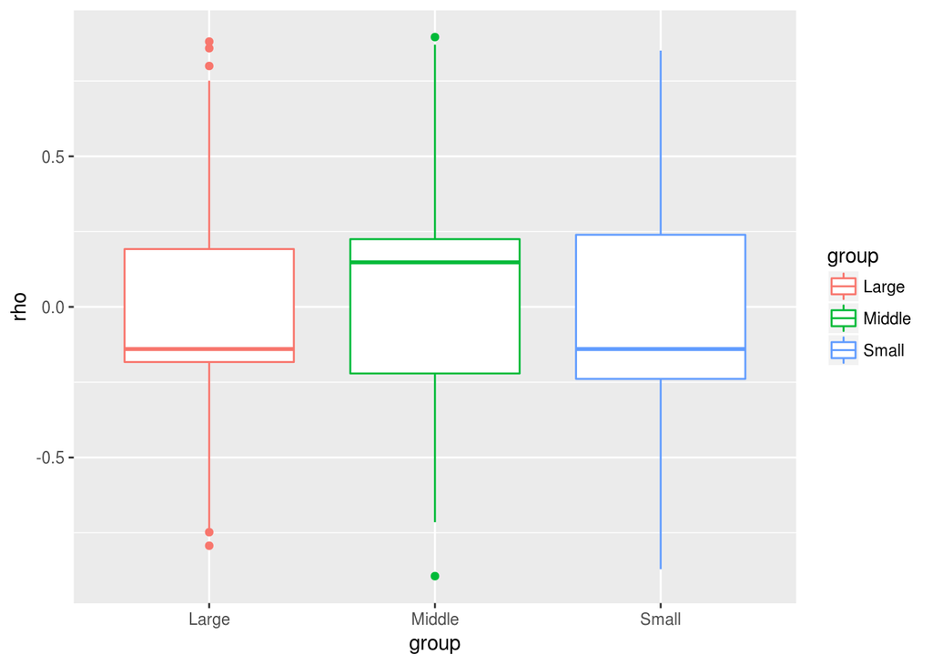

```r
dir_out <- "output_r"
pgen.0 <- pgen %>% rename(posSNP=`posSNP(hg18)`, posTSS=`posTSS(hg18)`)
pgen.1 <- pgen.0 %>% filter(str_detect(SNP, "^rs"))
pgen.2 <- pgen.1 %>% select(SNP, gene, chr=chrSNP, posSNP:pvalue) %>% mutate(chr=paste0("chr", chr))
pgen.3 <- pgen.2 %>% mutate(group=ifelse(distanceTSS>=50000, "Large", ifelse(distanceTSS>=20000, "Middle", "Small")))
write_tsv(pgen.3, file.path(dir_out, "pgen_brief.tsv"))
ggplot(pgen.3, aes(group, rho, color=group)) + geom_boxplot()
```

```r
ggsave(file.path(dir_out, "pgen_rho.png"))
```

#### 2.2.3.2 All-in-one

We can do this analysis all-in-one:

- From the beginning to the end like a pipeline or workflow
- Save resources by not using intermediate variables
- Can be extracted to a function for reuse

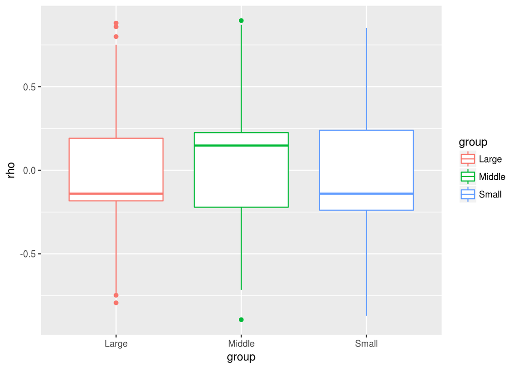

```r
pgen %>% rename(posSNP=`posSNP(hg18)`, posTSS=`posTSS(hg18)`) %>%
  filter(str_detect(SNP, "^rs")) %>%
  select(SNP, gene, chr=chrSNP, posSNP:pvalue) %>% mutate(chr=paste0("chr", chr)) %>%
  mutate(group=ifelse(distanceTSS>=50000, "Large", ifelse(distanceTSS>=20000, "Middle", "Small"))) %>% ggplot(aes(group, rho, color=group)) + geom_boxplot()
```

### 2.2.4 Perl solution

You must have a bird’s-eye view because data are processed row by row.

```perl
#!/usr/bin/perl

use warnings;
use strict;

my $dir_out = "output_perl";
mkdir $dir_out unless -d $dir_out;
my $fi      = "pgen.tsv";
my $fo      = "$dir_out/pgen_brief.tsv";
open my $I, '<', $fi or die "$0 : failed to open input file '$fi' : $!\n";
open my $O, '>', $fo or die "$0 : failed to open output file '$' : $!\n";
select $O;
print join "\t", "SNP", "gene", "chr", "posSNP", "posTSS", "distanceTSS", "rho", "pvalue", "group";
print "\n";

while (<$I>) {
    if (/^rs\d+/) {
        my @fields = split /\t/;
        my $chr    = "chr" . $fields[3];
        my $group =
          $fields[7] >= 50000
          ? "Large"
          : ( $fields[7] >= 20000 ? "Middle" : "Small" );
        print join "\t", $fields[0], $fields[2], $chr, @fields[ 5 .. 9 ], $group;
        print "\n";
    }
}
close $I or warn "$0 : failed to close input file '$fi' : $!\n";
close $O or warn "$0 : failed to close output file '$' : $!\n";
```

## 2.3 Genes

### 2.3.1 Read in data and understand it

```r
genes <- read_tsv("genes.tsv")
glimpse(genes)
```

```
## Observations: 27,008
## Variables: 15
## $ PharmGKB Accession Id     <chr> "PA24356", "PA165392995", "PA1623750...
## $ NCBI Gene ID              <int> 1, 503538, 29974, 2, 144568, 3, 1275...
## $ HGNC ID                   <int> 5, 37133, 24086, 7, 23336, 8, 30005,...
## $ Ensembl Id                <chr> "ENSG00000121410", NA, "ENSG00000148...
## $ Name                      <chr> "alpha-1-B glycoprotein", "A1BG anti...
## $ Symbol                    <chr> "A1BG", "A1BG-AS1", "A1CF", "A2M", "...
## $ Alternate Names           <chr> NA, NA, NA, NA, "CPAMD9", NA, "A3GAL...
## $ Alternate Symbols         <chr> NA, "FLJ23569", "ACF\",\"ACF64\",\"A...
## $ Is VIP                    <chr> "No", "No", "No", "No", "No", "No", ...
## $ Has Variant Annotation    <chr> "No", "No", "No", "Yes", "No", "No",...
## $ Cross-references          <chr> "NCBI Gene:1\",\"OMIM:138670\",\"UCS...
## $ Has CPIC Dosing Guideline <chr> "No", "No", "No", "No", "No", "No", ...
## $ Chromosome                <chr> "chr19", "chr19", "chr10", "chr12", ...
## $ Chromosomal Start         <int> 58855172, 58853336, 52556169, 921730...
## $ Chromosomal Stop          <int> 58874865, 58869549, 52655435, 927855...
```

```r
summary(genes)
```

```
##  PharmGKB Accession Id  NCBI Gene ID          HGNC ID
##  Length:27008          Min.   :        1   Min.   :    5
##  Class :character      1st Qu.:     8102   1st Qu.: 8652
##  Mode  :character      Median :    55762   Median :17018
##                        Mean   :  6794386   Mean   :17793
##                        3rd Qu.:   252952   3rd Qu.:26708
##                        Max.   :102724631   Max.   :51375
##                        NA's   :166         NA's   :762
##   Ensembl Id            Name              Symbol
##  Length:27008       Length:27008       Length:27008
##  Class :character   Class :character   Class :character
##  Mode  :character   Mode  :character   Mode  :character
##
##
##
##
##  Alternate Names    Alternate Symbols     Is VIP
##  Length:27008       Length:27008       Length:27008
##  Class :character   Class :character   Class :character
##  Mode  :character   Mode  :character   Mode  :character
##
##
##
##
##  Has Variant Annotation Cross-references   Has CPIC Dosing Guideline
##  Length:27008           Length:27008       Length:27008
##  Class :character       Class :character   Class :character
##  Mode  :character       Mode  :character   Mode  :character
##
##
##
##
##   Chromosome        Chromosomal Start   Chromosomal Stop
##  Length:27008       Min.   :       -1   Min.   :       -1
##  Class :character   1st Qu.: 21174526   1st Qu.: 21222713
##  Mode  :character   Median : 50636648   Median : 50677154
##                     Mean   : 65886391   Mean   : 65943756
##                     3rd Qu.:102361759   3rd Qu.:102400866
##                     Max.   :249190395   Max.   :249218453
##
```

### 2.3.2 Tasks to do

1. Drop records whose NCBI or HGNC or Ensembl ID is `NA`
2. Keep columns (PharmGKB, NCBI, Name, Symbol, Chr, Start, End)
3. Calaculate the length based on start and end of the chromosome
4. Arrange the columns
5. Plot the length distribution
6. Compara the numbers between chromosomes
   - data: sort by numbers from high to low
   - plot
7. Save data and plot

### 2.3.3 Analysis

#### 2.3.3.1 Step-by-step

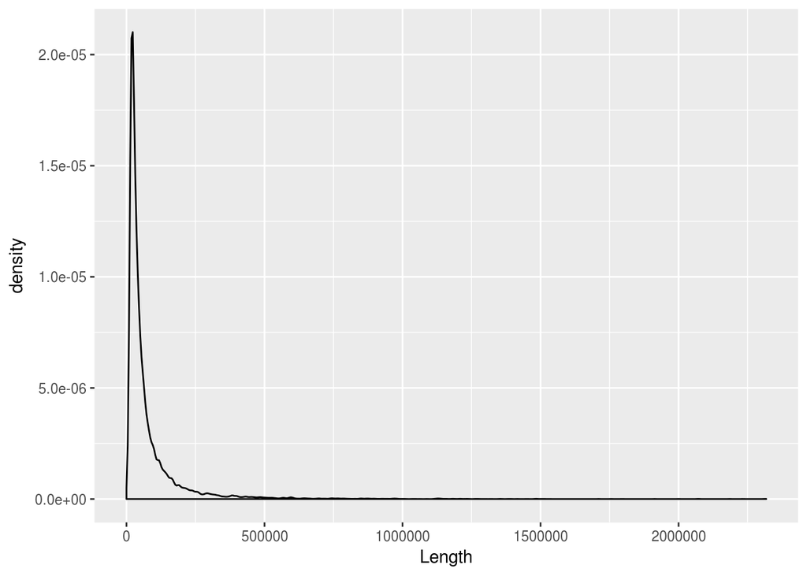

```r
dir_out <- "output_r"
genes.0 <- genes %>% rename(PharmGKB=`PharmGKB Accession Id`, NCBI=`NCBI Gene ID`, HGNC=`HGNC ID`, Ensembl=`Ensembl Id`, AltName=`Alternate Names`, AltSym=`Alternate Symbols`, Vip=`Is VIP`, Annotate=`Has Variant Annotation`, Ref=`Cross-references`, Guide=`Has CPIC Dosing Guideline`, Chr=Chromosome, Start=`Chromosomal Start`, End=`Chromosomal Stop`)
#ens_err <- genes.0 %>% filter(!str_detect(Ensembl, "^E\\w+\\d$") | is.na(Ensembl))
genes.1 <- genes.0 %>% drop_na(NCBI, HGNC, Ensembl)
genes.2 <- genes.1 %>% select(PharmGKB, NCBI, Name, Symbol, Chr, Start, End)
genes.3 <- genes.2 %>% mutate(Length=End-Start)
genes.4 <- genes.3 %>% select(PharmGKB, NCBI, Symbol:Length, Name)
write_tsv(genes.4, file.path(dir_out, "genes_brief.tsv"))
ggplot(genes.4, aes(Length)) + geom_density()
```

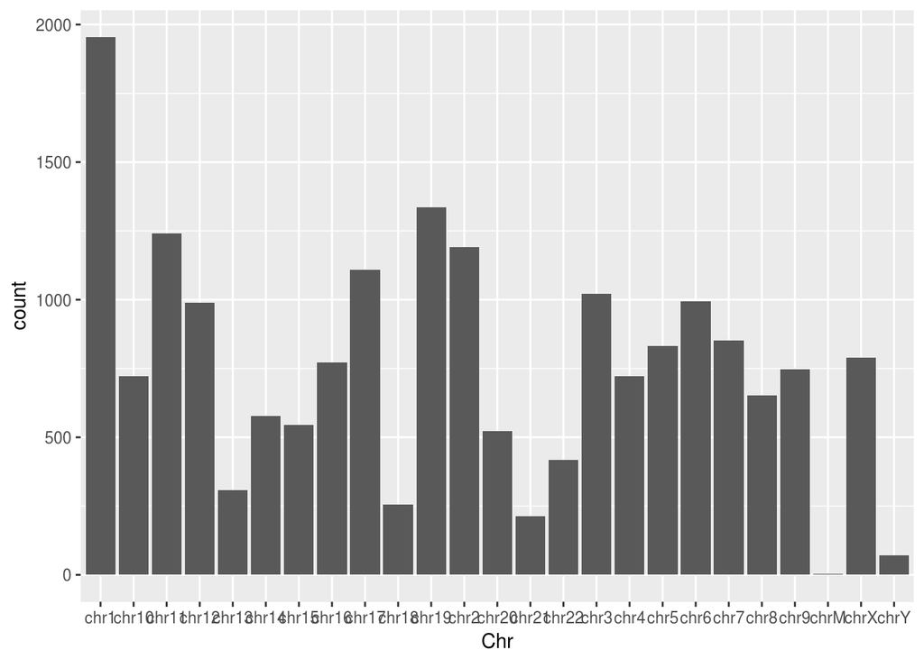

```r
ggsave(file.path(dir_out, "length_distribution.png"))
ggplot(genes.4, aes(Chr)) + geom_bar()
```

```r
ggsave(file.path(dir_out, "chr_number_barplot.png"))
chr_count <- genes.4 %>% group_by(Chr) %>% summarise(Count=n()) %>% arrange(desc(Count))
write_tsv(chr_count, file.path(dir_out, "genes_chr_number.tsv"))
```

#### 2.3.3.2 All-in-one

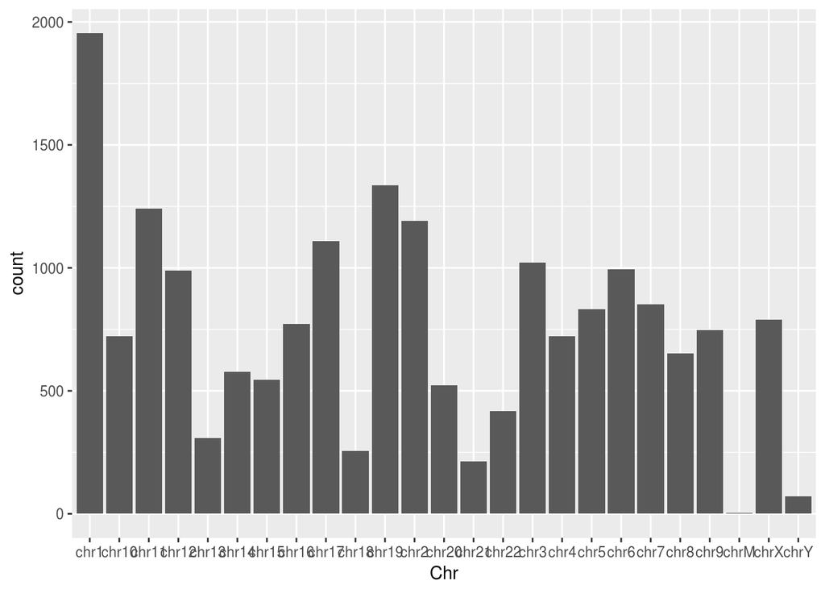

```r
genes %>% rename(PharmGKB=`PharmGKB Accession Id`, NCBI=`NCBI Gene ID`, HGNC=`HGNC ID`, Ensembl=`Ensembl Id`, AltName=`Alternate Names`, AltSym=`Alternate Symbols`, Vip=`Is VIP`, Annotate=`Has Variant Annotation`, Ref=`Cross-references`, Guide=`Has CPIC Dosing Guideline`, Chr=Chromosome, Start=`Chromosomal Start`, End=`Chromosomal Stop`) %>%
  drop_na(NCBI, HGNC, Ensembl) %>%
  select(PharmGKB, NCBI, Name, Symbol, Chr, Start, End) %>%
  mutate(Length=End-Start) %>%
  select(PharmGKB, NCBI, Symbol:Length, Name) %>%
  ggplot(aes(Chr)) + geom_bar()
```

### 2.3.4 Perl solution

```perl
#!/usr/bin/perl

use warnings;
use strict;

my $dir_out    = "output_perl";
mkdir $dir_out unless -d $dir_out;
my $file_genes = "genes.tsv";
my $file_out   = "$dir_out/genes_brief.tsv";
open my $I, '<', $file_genes or die "$0 : failed to open input file '$file_genes' : $!\n";
open my $O, '>', $file_out or die "$0 : failed to open output file '$file_out' : $!\n";
select $O;
print join "\t", "PharmGKB", "NCBI", "Symbol", "Chr", "Start", "End", "Length", "Name";
print "\n";
my %number;

while (<$I>) {
    chomp;
    unless (/^Pham/) {
        my @fields = split /\t/;
        if ( $fields[1] =~ /\d/ && $fields[2] =~ /\d/ && $fields[3] =~ /\w/ ) {
            my $length = $fields[-1] - $fields[-2];
            $number{ $fields[-3] }++;
            print join "\t", @fields[ 0, 1, 5, -3, -2, -1 ], $length, $fields[4];
            print "\n";
        }
    }
}
close $I or warn "$0 : failed to close input file '$file_genes' : $!\n";
close $O or warn "$0 : failed to close output file '$file_out' : $!\n";

my $file_number = "$dir_out/genes_chr_num.tsv";
open my $ON, '>', $file_number or die "$0 : failed to open output file '$file_number' : $!\n";
select $ON;
print "Chr\tCount\n";
foreach my $key ( sort { $number{$b} <=> $number{$a} } keys %number ) {
    print "$key\t$number{$key}\n";
}
close $ON or warn "$0 : failed to close output file '$file_number' : $!\n";
```

## 2.4 Phewas

### 2.4.1 Read in data and understand it

```r
phewas <- read_csv("phewas.csv", na=c("", "NA", "NULL"))
glimpse(phewas)
```

```
## Observations: 215,107
## Variables: 9
## $ chromosome        <chr> "19 45395619", "19 45395619", "6 396321", "6...
## $ snp               <chr> "rs2075650", "rs2075650", "rs12203592", "rs1...
## $ phewas phenotype  <chr> "Alzheimer's disease", "Dementias", "Actinic...
## $ cases             <int> 737, 1170, 2505, 40, 1566, 749, 1931, 40, 21...
## $ p-value           <dbl> 5.237e-28, 2.409e-26, 4.141e-26, 3.409e-25, ...
## $ odds-ratio        <dbl> 2.4100, 2.1140, 1.6910, 12.2700, 1.8410, 0.5...
## $ gene_name         <chr> "TOMM40", "TOMM40", "IRF4", "HFE", "TOMM40",...
## $ phewas code       <chr> "290.11", "290.1", "702.1", "275.1", "290", ...
## $ gwas-associations <chr> "Alzheimer's disease, Alzheimer's disease bi...
```

```r
summary(phewas)
```

```
##   chromosome            snp            phewas phenotype       cases
##  Length:215107      Length:215107      Length:215107      Min.   :  25
##  Class :character   Class :character   Class :character   1st Qu.:  80
##  Mode  :character   Mode  :character   Mode  :character   Median : 228
##                                                           Mean   : 582
##                                                           3rd Qu.: 615
##                                                           Max.   :8185
##     p-value          odds-ratio        gene_name
##  Min.   :0.00000   Min.   : 0.07705   Length:215107
##  1st Qu.:0.01241   1st Qu.: 0.77980   Class :character
##  Median :0.02497   Median : 1.12400   Mode  :character
##  Mean   :0.02494   Mean   : 1.11070
##  3rd Qu.:0.03747   3rd Qu.: 1.36400
##  Max.   :0.05000   Max.   :33.88000
##  phewas code        gwas-associations
##  Length:215107      Length:215107
##  Class :character   Class :character
##  Mode  :character   Mode  :character
##
##
##
```

### 2.4.2 Tasks to do

1. Drop records whose position is missing or gene name is NULL
2. Split chromosome and position, and format chromosome to “chrN”
3. Keep records whose cases number is more than 100 and its odds ratio is great than 1
4. Discard column codes and arrange remaining columns
5. Find the top 15 genes which have the most SNPs
   1. Count the SNP number for each gene
   2. Select the top 15 genes according to SNP number
   3. Restore the SNP infomation for these genes

### 2.4.3 Analysis

#### 2.4.3.1 Step-by-step

```r
dir_out <- "output_r"
phewas.0 <- phewas %>% rename(chrom=chromosome, phenotype=`phewas phenotype`, pvalue=`p-value`, ratio=`odds-ratio`, gene=gene_name, code=`phewas code`, gwas=`gwas-associations`)
phewas.1 <- phewas.0 %>% filter(str_detect(chrom, "\\w\\s\\d")) %>% drop_na(gene)
phewas.2 <- phewas.1 %>% separate(chrom, into=c("chr", "pos")) %>% mutate(chr=paste0("chr", chr))
phewas.3 <- phewas.2 %>% filter(cases>=100 & ratio>=1)
phewas.4 <- phewas.3 %>% select(chr:snp, cases:gene, phenotype, gwas)
write_csv(phewas.4, file.path(dir_out, "phewas_brief.csv"))
gene_snp <- phewas.4 %>% group_by(gene) %>% summarise(number=n()) %>% top_n(15, number) %>% arrange(desc(number))
top15_gene <- inner_join(phewas.4, gene_snp) %>% arrange(desc(number))
write_csv(top15_gene, file.path(dir_out, "top15_gene.csv"))
```

#### 2.4.3.2 All-in-one

```r
phewas.brief <- phewas %>% rename(chrom=chromosome, phenotype=`phewas phenotype`, pvalue=`p-value`, ratio=`odds-ratio`, gene=gene_name, code=`phewas code`, gwas=`gwas-associations`) %>%
  filter(str_detect(chrom, "\\w\\s\\d")) %>% drop_na(gene) %>%
  separate(chrom, into=c("chr", "pos")) %>% mutate(chr=paste0("chr", chr)) %>%
  filter(cases>=100 & ratio>=1) %>%
  select(chr:snp, cases:gene, phenotype, gwas)
top15_gene <- phewas.brief %>% group_by(gene) %>% summarise(number=n()) %>% top_n(15, number) %>%
  inner_join(phewas.brief, .) %>% arrange(desc(number))
```

### 2.4.4 Perl solution

```perl
#!/usr/bin/perl

use warnings;
use strict;

use Text::CSV;
my $csv = Text::CSV->new( { binary => 1 } ) or die "Cannot use CSV: " . Text::CSV->error_diag();

my $dir_out  = "output_perl";
mkdir $dir_out unless -d $dir_out;
my $file_in  = "phewas.csv";
my $file_out = "$dir_out/phewas_brief.csv";
open my $I, '<:encoding(utf8)', $file_in or die "$0 : failed to open input file '$file_in' : $!\n";
open my $O, '>:encoding(utf8)', $file_out or die "$0 : failed to open output file '$' : $!\n";
my @header;
push @header, "chr", "pos", "snp", "cases", "pvalue", "ratio", "gene", "pehnotype", "gwas";
$csv->say( $O, \@header );
my %gene;

while ( my $row = $csv->getline($I) ) {
    my @fields = @$row;
    if ( $fields[0] =~ /\w\s\d/ && $fields[6] ne "NULL" ) {
        if ( $fields[3] >= 100 && $fields[5] >= 1 ) {
            my ( $chr, $pos ) = split /\s+/, $fields[0];
            $chr = "chr" . $chr;
            my $value = join "\t", $chr, $pos, $fields[1], @fields[ 3 .. 6 ], $fields[2], $fields[-1];
            my @record = split /\t/, $value;
            $csv->say( $O, \@record );
            push @{ $gene{ $fields[6] } }, $value;
        }
    }
}
$csv->eof or $csv->error_diag();
close $I  or warn "$0 : failed to close input file '$file_in' : $!\n";
close $O  or warn "$0 : failed to close output file '$file_out' : $!\n";

my $file_gene = "$dir_out/top15_gene.csv";
open my $G, '>:encoding(utf8)', $file_gene or die "$0 : failed to open output file '$file_gene' : $!\n";
push @header, "number";
$csv->say( $G, \@header );
my $i = 15;
foreach my $key ( sort { @{ $gene{$b} } <=> @{ $gene{$a} } } keys %gene ) {
    if ( $i > 0 ) {
        foreach my $snp ( @{ $gene{$key} } ) {
            my @record = split /\t/, $snp;
            push @record, scalar( @{ $gene{$key} } );
            $csv->say( $G, \@record );
        }
    }
    $i--;
}
close $G or warn "$0 : failed to close output file '$file_gene' : $!\n";
```